# sensemakr: Sensitivity Analysis Tools for OLS

[figure not shown]

[figure not shown]

`sensemakr` implements a suite of sensitivity analysis tools that extends the traditional omitted variable bias framework and makes it easier to understand the impact of omitted variables in regression models, as discussed in [Cinelli, C. and Hazlett, C. (2020) “Making Sense of Sensitivity: Extending Omitted Variable Bias.” Journal of the Royal Statistical Society, Series B (Statistical Methodology).](https://doi.org/10.1111/rssb.12348)

# News

- Watch the [useR! 2020 presentation](https://www.youtube.com/watch?v=p3dfHj6ki68) for a quick introduction on sensemakr.
- Check out the [software paper preprint](https://www.researchgate.net/publication/340965014_sensemakr_Sensitivity_Analysis_Tools_for_OLS_in_R_and_Stata)!
- Check out the [Stata version](https://github.com/resonance1/sensemakr-stata) of the package!
- Check out the [Python version](https://github.com/nlapier2/PySensemakr) of the package!
- Check out the Robustness Value Shiny App at: https://carloscinelli.shinyapps.io/robustness_value/
- Check out the [package website](http://carloscinelli.com/sensemakr/)!

# Details

For theoretical details, [please see the JRSS-B paper](https://www.researchgate.net/publication/322509816_Making_Sense_of_Sensitivity_Extending_Omitted_Variable_Bias).

For a practical introduction, [please see the software paper](https://www.researchgate.net/publication/340965014_sensemakr_Sensitivity_Analysis_Tools_for_OLS_in_R_and_Stata) or [see the package vignettes](http://carloscinelli.com/sensemakr/articles/sensemakr.html).

For a quick start, watch the 15 min tutorial on sensitivity analysis using sensemakr prepared for useR! 2020:

[video not shown]

# CRAN

To install the current CRAN version run:

```r
install.packages("sensemakr")
```

# Development version

To install the development version on GitHub make sure you have the package `devtools` installed.

```r
# install.packages("devtools")
devtools::install_github("carloscinelli/sensemakr")
```

# Citation

Please use the following citations:

- [Cinelli, C., & Hazlett, C. (2020). “Making sense of sensitivity: Extending omitted variable bias.” Journal of the Royal Statistical Society: Series B (Statistical Methodology), 82(1), 39-67.](https://doi.org/10.1111/rssb.12348)
- [Cinelli, C., & Ferwerda, J., & Hazlett, C. (2020). “sensemakr: Sensitivity Analysis Tools for OLS in R and Stata.”](https://www.researchgate.net/publication/340965014_sensemakr_Sensitivity_Analysis_Tools_for_OLS_in_R_and_Stata)

# Basic usage

```r
# loads package
library(sensemakr)
# loads dataset
data("darfur")

# runs regression model
model <- lm(peacefactor ~ directlyharmed + age + farmer_dar + herder_dar +
                         pastvoted + hhsize_darfur + female + village, data = darfur)

# runs sensemakr for sensitivity analysis
sensitivity <- sensemakr(model = model,
                         treatment = "directlyharmed",
                         benchmark_covariates = "female",
                         kd = 1:3)

# short description of results
sensitivity
```

```
#> Sensitivity Analysis to Unobserved Confounding
#>
#> Model Formula: peacefactor ~ directlyharmed + age + farmer_dar + herder_dar +
#>     pastvoted + hhsize_darfur + female + village
#>
#> Null hypothesis: q = 1 and reduce = TRUE
#>
#> Observed Estimates of ' directlyharmed ':
#>   Coef. estimate: 0.09732
#>   Standard Error: 0.02326
#>   t-value: 4.18445
#>
#> Sensitivity Statistics:
#>   Partial R2 of treatment with outcome: 0.02187
#>   Robustness Value, q = 1 : 0.13878
#>   Robustness Value, q = 1 alpha = 0.05 : 0.07626
#>
#> For more information, check summary.
```

```r
# long description of results
summary(sensitivity)
```

[output not shown]

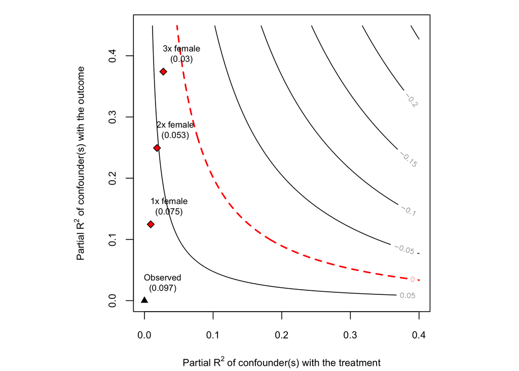

```r
# plot bias contour of point estimate
plot(sensitivity)
```

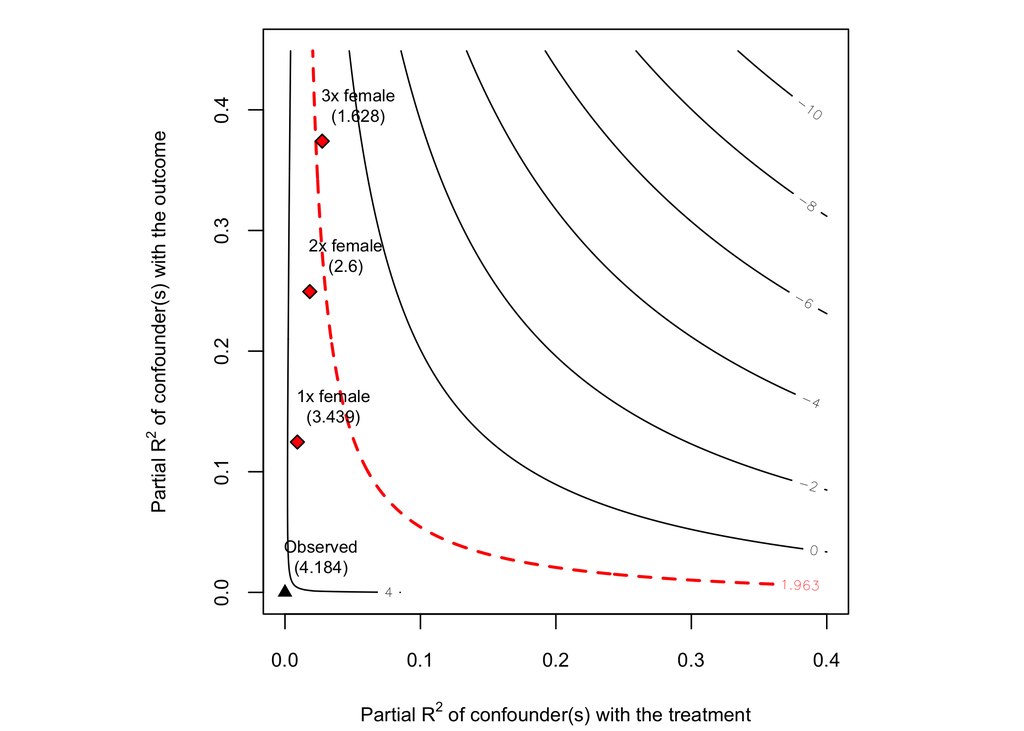

```r
# plot bias contour of t-value
plot(sensitivity, sensitivity.of = "t-value")
```

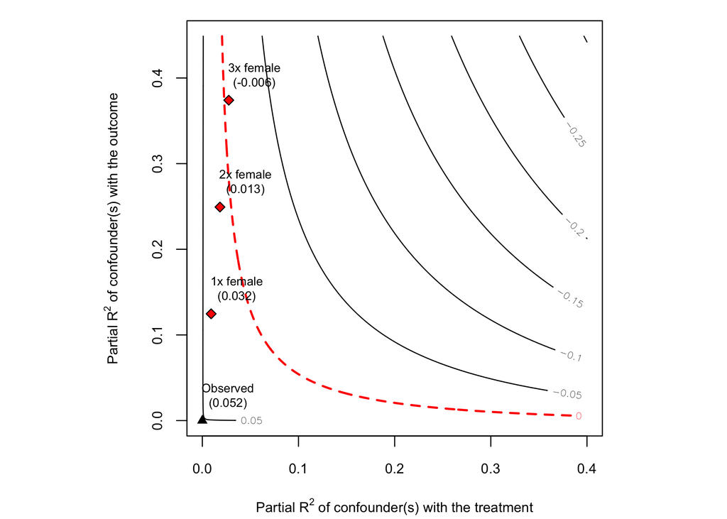

```r
# plot bias contour of lower limit of confidence interval
plot(sensitivity, sensitivity.of = "lwr")
```

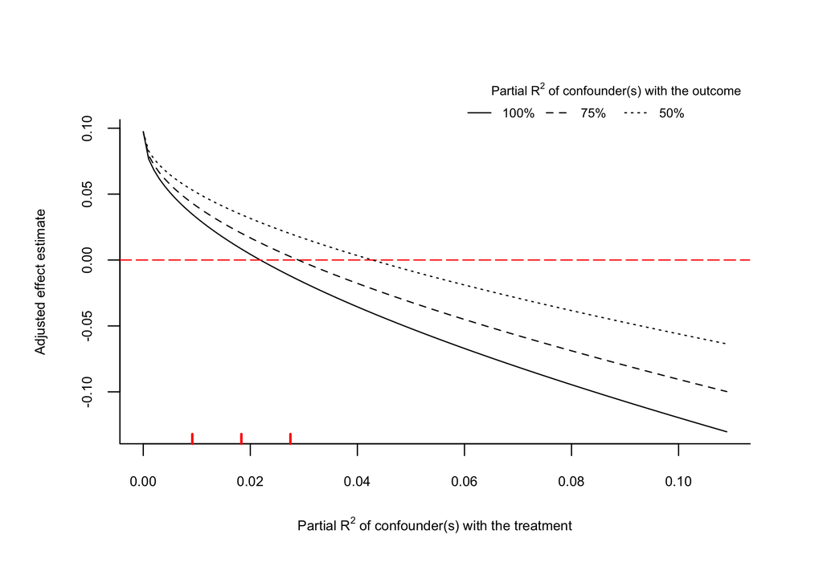

```r
# plot extreme scenario
plot(sensitivity, type = "extreme")
```

```r
# latex code for sensitivity table
ovb_minimal_reporting(sensitivity)
```

```
#> \begin{table}[!h]
#> \centering
#> \begin{tabular}{lrrrrrr}
#> \multicolumn{7}{c}{Outcome: \textit{peacefactor}} \\
#> \hline \hline
#> Treatment: & Est. & S.E. & t-value & $R^2_{Y \sim D |{\bf X}}$ & $RV_{q = 1}$ & $RV_{q = 1, \alpha = 0.05}$  \\
#> \hline
#> \textit{directlyharmed} & 0.097 & 0.023 & 4.184 & 2.2\% & 13.9\% & 7.6\% \\
#> \hline
#> df = 783 & & \multicolumn{5}{r}{ \small \textit{Bound (1x female)}: $R^2_{Y\sim Z| {\bf X}, D}$ = 12.5\%, $R^2_{D\sim Z| {\bf X} }$ = 0.9\%} \\
#> \end{tabular}
#> \end{table}
```

```r
# html code for sensitivity table
ovb_minimal_reporting(sensitivity, format = "pure_html")
```

| Treatment | Outcome: peacefactor Est. | Outcome: peacefactor S.E. | Outcome: peacefactor t-value | Outcome: peacefactor R<sup>2</sup><sub>Y~D\|X</sub> | Outcome: peacefactor RV<sub>q = 1</sub> | Outcome: peacefactor RV<sub>q = 1, α = 0.05</sub> |
| --- | --- | --- | --- | --- | --- | --- |
| *directlyharmed* | 0.097 | 0.023 | 4.184 | 2.2% | 13.9% | 7.6% |
| Note: df = 783; Bound ( 1x female ): R<sup>2</sup><sub>Y~Z\|X,D</sub> = 12.5%, R<sup>2</sup><sub>D~Z\|X</sub> = 0.9% |  |  |  |  |  |  |